# UNIT2C：Comics Dataset (1)

中山大學管理學院 卓雍然

2022-03-07 22:15:57

[figure not shown]

在繼續之前，let’s have some fun! 在這程式筆記中，我們將使用漫畫人物的資料集來回顧、介紹和練習 R 的內建函數。 ( [資料來源: Kaggle.com](https://www.kaggle.com/fivethirtyeight/fivethirtyeight-comic-characters-dataset) )

### 1. 讀入並檢查資料框的結構

🌻 `read.csv()` - 讀取CSV（逗號分隔值）的文件

```r
D = read.csv("data/comics1.csv")
```

🌻 `nrow()` - 確認row的數量

```r
nrow(D)
```

```
[1] 7250
```

🌻 `ncol()` - 確認column的數量

```r
ncol(D)
```

```
[1] 9
```

資料框之中 …

- 一個`row`又稱為一筆資料或一筆紀錄(record)，它代表一個研究對象、一個分析單位
- 一個`column`又稱為一個欄位、變數(variables)或屬性(attributes)，它代表研究對象的某個屬性或量測值

🌻 `str()` - 用來檢查資料框的結構，每個column的資料種類

```r
str(D)
```

```
'data.frame':   7250 obs. of  9 variables:
 $ publisher  : chr  "dc" "dc" "dc" "dc" ...
 $ name       : chr  "Batman (Bruce Wayne)" "Superman (Clark Kent)" "Green Lantern (Hal Jordan)" "James Gordon (New Earth)" ...
 $ align      : chr  "Good" "Good" "Good" "Good" ...
 $ eye        : chr  "Blue" "Blue" "Brown" "Brown" ...
 $ hair       : chr  "Black" "Black" "Brown" "White" ...
 $ sex        : chr  "Male" "Male" "Male" "Male" ...
 $ alive      : chr  "Living" "Living" "Living" "Living" ...
 $ appearances: int  3093 2496 1565 1316 1237 1231 1121 1095 1075 1028 ...
 $ year       : int  1939 1986 1959 1987 1940 1941 1941 1989 1969 1956 ...
```

### 2. 檢查變數

🌻 `summary()` 是檢查資料框(每個column的)內容最方便的方式

```r
summary(D)
```

```
  publisher             name              align               eye
 Length:7250        Length:7250        Length:7250        Length:7250
 Class :character   Class :character   Class :character   Class :character
 Mode  :character   Mode  :character   Mode  :character   Mode  :character



     hair               sex               alive            appearances
 Length:7250        Length:7250        Length:7250        Min.   :   1
 Class :character   Class :character   Class :character   1st Qu.:   3
 Mode  :character   Mode  :character   Mode  :character   Median :   8
                                                          Mean   :  42
                                                          3rd Qu.:  26
                                                          Max.   :4043
      year
 Min.   :1936
 1st Qu.:1978
 Median :1992
 Mean   :1989
 3rd Qu.:2004
 Max.   :2013
```

🗿 QUIZ 2：  
■ 這個資料框的名字是什麼?  
■ 我們要分析的目標對象是什麼?  
■ 我們感興趣的屬性是哪些?  
■ 資料集有哪些是數值型的column ?  
■ 資料集有哪些是字串型的column ?  
■ 哪些是字串型的column是**類別** 欄位呢?

```r
# D
# name (角色)
# All variable
# appearances & year
# name (加上下面可轉類別的變數)
# align & eye & hair & alive & publisher & sex
```

🌷 請注意，對不同資料種類的欄位，`summary()`會以不同的方式進行匯總

- 對於**數值**欄位，會以**統計量**的方式回報該變數的**分佈**
- 對於**字串**欄位，只顯示它們的種類
- 對於**類別**欄位，會顯示各類別的分佈 (後面會詳細說明)

💡 分佈 & 統計量  
■ **分佈** : 是一種描述變數的方式，它描述著 …  
◇ 變數值的變化  
◇ 也就是說，變數的值是如何分佈的?  
■ **統計量** : 數值變數的某種具體特徵  
◇ 舉例來說: 平均(mean), 中位數(median), 最小值(min), 最大值(max)  
■ 變數的分佈可以用兩種型式表示 :  
◇ 在數字上， 用統計量表示 或者  
◇ 以圖形上，用繪圖的方式表示

##### 2.1 檢查數值(連續)變數

🌻 `mean()`, `median`, `max`, `min()` - 取得數值變數的個別統計量

```r
c( mean=mean(D$year), median=median(D$year),
   max=max(D$year), min=min(D$year)  )
```

```
  mean median    max    min
  1989   1992   2013   1936
```

🌻 `summary` 一次獲得所有主要的統計量

```r
summary(D$year)
```

```
   Min. 1st Qu.  Median    Mean 3rd Qu.    Max.
   1936    1978    1992    1989    2004    2013
```

🌻 `hist()` - 畫出數值變數的分佈  
🌻 `log()` 當分佈很不均勻時，對數函數有助於壓制極端值的視覺衝擊

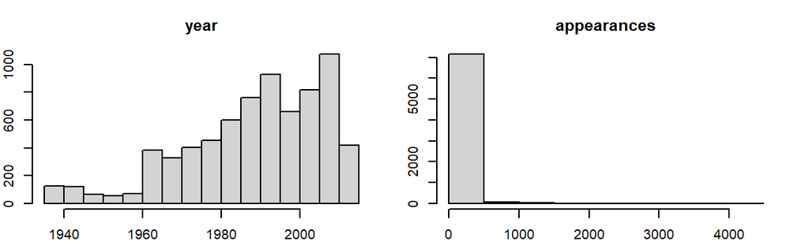

```r
par(mfrow=c(1,2), mar=c(2,2,3,2), cex=0.6)  # 2 plots in a row, smaller font
hist(D$year, main="year")
hist(D$appearances, main="appearances")
```

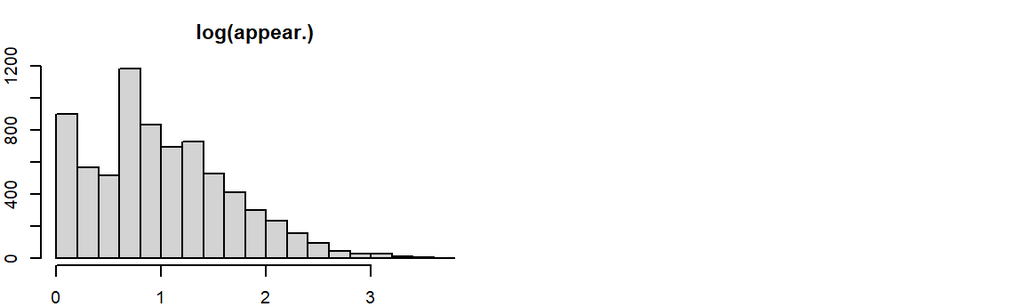

```r
log(D$appearances,10) %>% hist(main="log(appear.)")
#出現1、10、100、1000次
```

##### 2.2 檢查類別(離散型)變數

🌻 `table()` 列出並各類別的個數

```r
table(D$align)
```

```
    Bad    Good Neutral
   2915    3178    1157
```

請注意，它是依類別名稱的字母順序排列

🌻 `barplot()` 視覺化離散變數的分佈

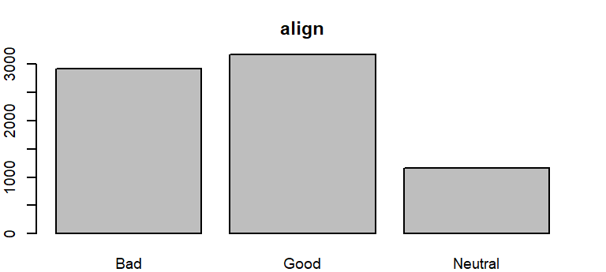

```r
par(mfrow=c(1,1), cex=0.6)  # 1 plots in a row
table(D$align) %>% barplot(main="align")
```

🗿 QUIZ 2.2  
■ **分佈**是什麼意思?  
■ 我們如何檢查 **數值** 變數的分佈?  
■ 我們如何檢查 **類別** 變數的分佈？  
■ 我們可以以**統計量**或**圖形**檢查變數，哪種方式比較好呢?  
■ …  
■ 以統計量檢查變數 `appearances`  
■ 以圖形方式檢查變數 `year`  
■ 以統計量檢查變數 `sex`  
■ 以圖形方式檢查變數 `eye`

```r
# 指散佈（在一定的地區內）可看出大致資料形狀，是一種描述變數的方式

#檢查數值(連續)變數:mean(), median, max, min(),summary(),hist()
#檢查類別(離散型)變數:table(),barplot()

# 數值大部分利用統計量 用summary() 也可畫箱型圖等
# 類別可畫圖詮釋 用table、barplot、圓餅圖等
# 每種變數有個別適合的方法，最好呈現方式因人而異(分數值、類別考慮)

summary(D$appearances)  #fivenum(D$appearances)
```

```
   Min. 1st Qu.  Median    Mean 3rd Qu.    Max.
      1       3       8      42      26    4043
```

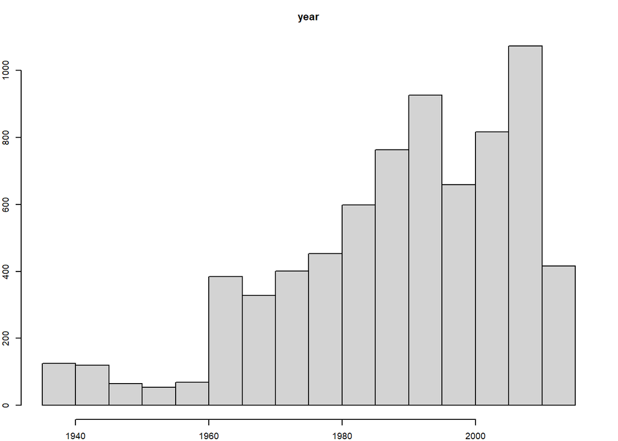

```r
hist(D$year,xlab = 'year',main = 'year')
```

```r
table(D$sex)
```

```
Female   Male
  2372   4878
```

```r
table(D$eye)
```

```
 Black   Blue  Brown  Green others    Red  White Yellow
   619   2477   2210    664    359    423    291    207
```

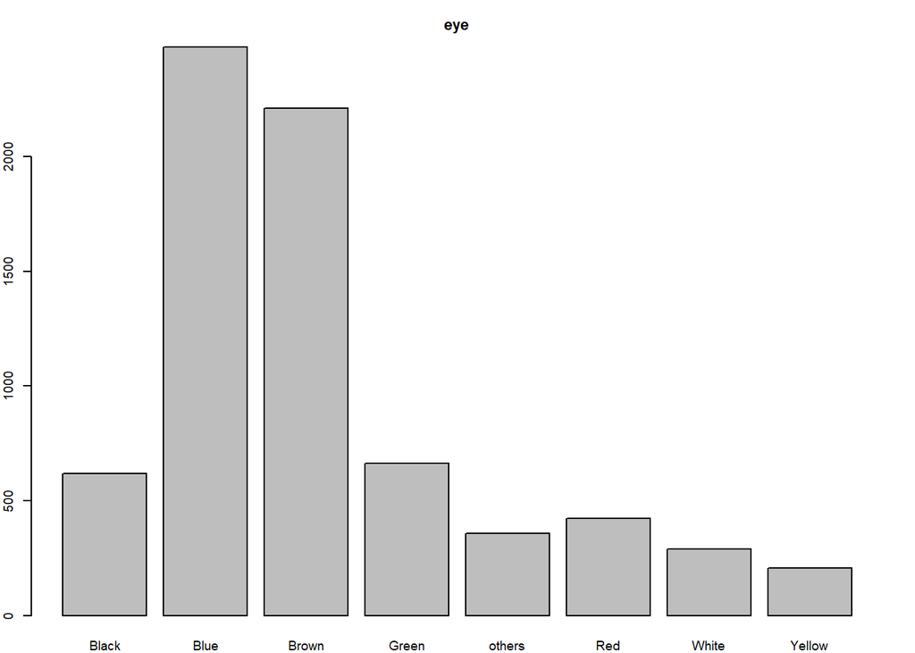

```r
barplot(table(D$eye),main = 'eye')
```

### 3. 字串(Character) vs. 因素(Factor)

在R裡面，原始資料之中的字串欄位可以被儲存為因素(`factor`)或字串(`character`)變數， 這兩種變數之間可以相互轉換。 好比說，`align`這個欄位一開始是被當作字串變數讀入， 我們可以用以下的指令將其轉變為一個具有3個不同的類別(levels)的因素變數`f.align`

🌻 `factor()` - 將字串向量轉為因素向量

```r
D$f.align = factor(D$align, levels=c("Good","Neutral","Bad"))
```

有需要的話，我們可以指定因素變數之中各類別(`levels`)的排列順序

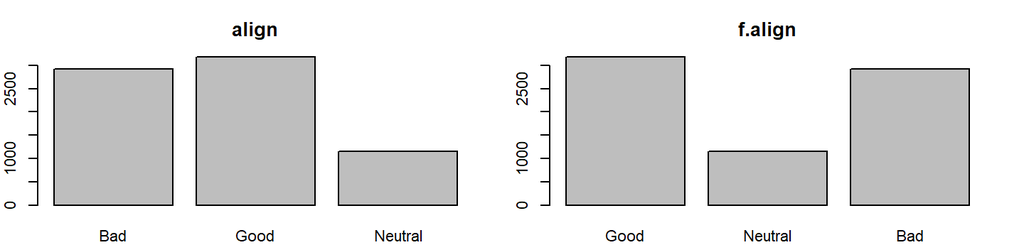

```r
par(mfrow=c(1,2), cex=0.7)
table(D$align) %>% barplot(main="align")
table(D$f.align) %>% barplot(main="f.align")
```

我們將 `eye`也轉為因素變數

```r
D$eye = factor(D$eye)
```

現在，它變成了 8 個類別(levels)的因素變數

```r
str(D$eye)
```

```
 Factor w/ 8 levels "Black","Blue",..: 2 2 3 3 2 2 2 2 2 2 ...
```

🌻 `level(x)` 列出因素變數`x`之中的所有類別

```r
levels(D$eye)
```

```
[1] "Black"  "Blue"   "Brown"  "Green"  "others" "Red"    "White"  "Yellow"
```

若我們在 `factor()` 中沒有指定 `levels`時，各類別將以英文字母的順序排列

```r
table(D$eye)
```

```
 Black   Blue  Brown  Green others    Red  White Yellow
   619   2477   2210    664    359    423    291    207
```

🌻 `sort()` 對向量進行(升冪)排列

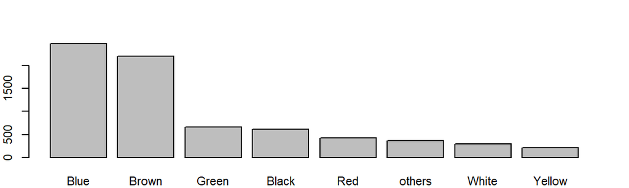

```r
par(mfrow=c(1,1), cex=0.7)
table(D$eye) %>% sort(dec=T) %>% barplot
```

```r
summary(D)
```

```
  publisher             name              align                eye
 Length:7250        Length:7250        Length:7250        Blue   :2477
 Class :character   Class :character   Class :character   Brown  :2210
 Mode  :character   Mode  :character   Mode  :character   Green  : 664
                                                          Black  : 619
                                                          Red    : 423
                                                          others : 359
                                                          (Other): 498
     hair               sex               alive            appearances
 Length:7250        Length:7250        Length:7250        Min.   :   1
 Class :character   Class :character   Class :character   1st Qu.:   3
 Mode  :character   Mode  :character   Mode  :character   Median :   8
                                                          Mean   :  42
                                                          3rd Qu.:  26
                                                          Max.   :4043

      year         f.align
 Min.   :1936   Good   :3178
 1st Qu.:1978   Neutral:1157
 Median :1992   Bad    :2915
 Mean   :1989
 3rd Qu.:2004
 Max.   :2013
```

🌷 在 `summary()` 中，因素 (或類別) 變數最多只會列出 6 筆資料，其他則歸類為 Other 。

💡字串 (Character) vs. 因素 (Factor)  
■ 字串和因素都可以用於表示類別變數。  
■ 雖然儲存和呈現的方式不盡相同，但大多數的情況兩者可以交換使用。  
■ 某些類別 columns 可能會以字串的形式被讀入。  
■ 所以，我們應該檢查每一 column 的變數型態。  
■ 通常，我們只需維持它們的原樣，在必要時將它們轉換型態即可。

### 4. 排序 (Order) 和 篩選 (Filter)

如果我們想要列出出現次數(`appearances`)最多的10個漫畫人物 …

##### 4.1 Sorting 和 Ordering 的區別

我們可以以降冪的方式(`decreasing=T`)對`D$appearances`進行`sort()`並 使用`head()`從向量中挑選出最前面10個值

```r
sort(D$appearances, decreasing=T) %>% head(10)
```

```
 [1] 4043 3360 3093 3061 2961 2496 2258 2255 2072 2017
```

這樣我們可以看到`D$appearances`之中最大的10個數字，但 … 他們是誰呢？

🌻 `sort(x)` 對`x`的內容進行排序並返回結果  
🌻 `order(x)` 依`x`的內容排序建立一個索引向量，(用來重新排序其他的物件)

```r
D[order(D$appearances,decreasing=T), c("year","appearances","name")] %>% head(10)
```

```
     year appearances                                  name
2424 1962        4043             Spider-Man (Peter Parker)
2425 1941        3360       Captain America (Steven Rogers)
1    1939        3093                  Batman (Bruce Wayne)
2426 1974        3061 Wolverine (James \\"Logan\\" Howlett)
2427 1963        2961   Iron Man (Anthony \\"Tony\\" Stark)
2    1986        2496                 Superman (Clark Kent)
2428 1950        2258                   Thor (Thor Odinson)
2429 1961        2255            Benjamin Grimm (Earth-616)
2430 1961        2072             Reed Richards (Earth-616)
2431 1962        2017            Hulk (Robert Bruce Banner)
```

如此我們可以按順序看到前10名最常出現的角色的出現年分(`year`)、出現次數(`appearances`)和名稱 (`name`)。

##### 4.2 有條件的進行篩選 (Order)

🌻 `subset(x, 條件, select=y)` 依照所給定的條件篩選row，並依欄位名稱選擇column

```r
d = subset(D, alive=="Deceased" & sex=="Female", select=c("year","appearances","name"))
d[order(d$appearances, decreasing=T), ] %>% head(10)
```

```
     year appearances                          name
2450 1963        1107         Jean Grey (Earth-616)
2510 1965         384  Gwendolyne Stacy (Earth-616)
50   1999         301   Kendra Saunders (New Earth)
2569 1975         259     Moira Kinross (Earth-616)
2571 1972         257 Namorita Prentiss (Earth-616)
2597 1964         226        Karen Page (Earth-616)
85   1971         216         Big Barda (New Earth)
103  1971         177     Talia al Ghul (New Earth)
2650 1964         170              Hela (Earth-616)
2651 1976         170 Lilandra Neramani (Earth-616)
```

以上，我們可以看到前10名出現次數最多的已故女性角色。

🗿 QUIZ 4.2  
■ 列出出現次數為前 10 名的金髮綠眼女性角色  
■ 列出 5 個最早出現的紅髮、紅眼男性的 `year`, `publisher`, `align`, 和 `name`

```r
d = subset(D, hair=="Blond" & eye=="Green" & sex=="Female", select=c("year","name",'appearances'))
d[order(d$appearances, decreasing=T), ] %>% head(10)
```

```
     year                         name appearances
2567 1979     Melissa Gold (Earth-616)         260
2578 1964            Amora (Earth-616)         247
2788 2005     Layla Miller (Earth-616)         108
207  1982    Lyla Michaels (New Earth)         105
280  1998    Cameron Chase (New Earth)          80
2929 1976     Jean DeWolff (Earth-616)          69
2930 1980 Blanche Sitznski (Earth-616)          69
3245 1971          Jarella (Earth-616)          38
3620 1999   Adrienne Frost (Earth-616)          24
835  1994 Alexandra DeWitt (New Earth)          19
```

```r
d = subset(D, eye=="Red" & hair=="Red" & sex=="Male",
           select=c('year',"publisher","align","name"))
d[order(d$year, decreasing=T), ] %>% tail(10)
```

```
     year publisher   align                              name
2193 1985        dc    Good           Prince Ruby (New Earth)
815  1984        dc     Bad         Arnold Pruett (New Earth)
1211 1983        dc     Bad               Maaldor (New Earth)
2037 1983        dc    Good                 Taren (New Earth)
373  1981        dc     Bad                Trigon (New Earth)
5248 1979    marvel     Bad             Torgo Nia (Earth-616)
2582 1973    marvel Neutral      Daimon Hellstrom (Earth-616)
770  1969        dc     Bad                Phobos (New Earth)
360  1947        dc     Bad           Per Degaton (New Earth)
6576 1943    marvel     Bad Satan (Destroyer Foe) (Earth-616)
```

### 5. 計數和比例

📋 為每個程式碼區塊寫下註解，將其作為自己的筆記本。

##### 5.1 使用邏輯運算式計算數量和比例

🌻 用 `sum()` 來計算一個邏輯向量裡面 `TRUE` 的個數

```r
#好人的數量
sum(D$align == "Good")
```

```
[1] 3178
```

🌻 用 `mean()` 來計算一個邏輯向量裡面 `TRUE` 的比例

```r
#好人的比例
mean(D$align == "Good")
```

```
[1] 0.4383
```

##### 5.2 `table()`和`prop.table()`

🌻 `table()` 列出一個向量裡各不同的值出現的次數

```r
#好人壞人中立的人數
table(D$align)
```

```
    Bad    Good Neutral
   2915    3178    1157
```

🌻 `prop.table()` 將計數轉換成比例

```r
#壞人好人中立的比例
table(D$align) %>% prop.table
```

```
    Bad    Good Neutral
 0.4021  0.4383  0.1596
```

如果我們在`table()`中放入兩個變數，會發生什麼事呢?

```r
#用align 和sex 分類出各人數
table(D$f.align, D$sex)
```

```
          Female Male
  Good      1264 1914
  Neutral    432  725
  Bad        676 2239
```

查看`prop.table`的線上說明(F1)，它的`margin`這個參數的作用是什麼？

```r
#用align 和sex 分類出各人數比例 (總為1)
#align 且 sex 的比例
table(D$f.align, D$sex) %>% prop.table
```

```
           Female    Male
  Good    0.17434 0.26400
  Neutral 0.05959 0.10000
  Bad     0.09324 0.30883
```

```r
#用align 和sex 分類出各人數比例 (各row加總為1)
#align 下 sex 的比例
table(D$f.align, D$sex) %>% prop.table(1)
```

```
          Female   Male
  Good    0.3977 0.6023
  Neutral 0.3734 0.6266
  Bad     0.2319 0.7681
```

```r
#用align 和sex 分類出各人數比例 (各column加總為1)
#sex 下 align 的比例
table(D$f.align, D$sex) %>% prop.table(2)
```

```
          Female   Male
  Good    0.5329 0.3924
  Neutral 0.1821 0.1486
  Bad     0.2850 0.4590
```

```r
#margin: 1 indicates rows
#        2 indicates columns
#        c(1, 2) indicates rows and columns.
```

我們來練習一下,

- 資料中有多少個壞男人 ❓

```r
table(D$f.align, D$sex)
```

```
          Female Male
  Good      1264 1914
  Neutral    432  725
  Bad        676 2239
```

```r
table(D$f.align, D$sex)[3,2]
```

```
[1] 2239
```

- 壞角色之中有多少比率是女的 ❓

```r
table(D$f.align, D$sex) %>% prop.table(1)
```

```
          Female   Male
  Good    0.3977 0.6023
  Neutral 0.3734 0.6266
  Bad     0.2319 0.7681
```

```r
J = table(D$f.align, D$sex) %>% prop.table(1)
J[3,1]
```

```
[1] 0.2319
```

- 女性之中有多少比率是壞人 ❓

```r
table(D$f.align, D$sex) %>% prop.table(2)
```

```
          Female   Male
  Good    0.5329 0.3924
  Neutral 0.1821 0.1486
  Bad     0.2850 0.4590
```

```r
W = table(D$f.align, D$sex) %>% prop.table(2)
W[3,1]
```

```
[1] 0.285
```

🏆 Group Competition Round 1

### 6. 分類統計與分群運算

##### 6.1 分類統計

要回答上面最後兩個問題，分別需要做兩次`table()`； 實際上，我們有有更簡便的方法

🌻 `tapply(value, group, fun)`依據`group`對`value`做`fun`

```r
tapply(D$align == "Neutral", D$sex, sum)
```

```
Female   Male
   432    725
```

按性別計算中立的人數

```r
tapply(D$align == "Neutral", D$sex, mean)
```

```
Female   Male
0.1821 0.1486
```

按性別統計中立的人的比例

我們來練習一下,

- 每種頭髮顏色中女性的比例分別是多少 ❓

```r
table(D$hair,D$sex) %>% prop.table(1)
```

```
          Female    Male
  Bald   0.05921 0.94079
  Black  0.34754 0.65246
  Blond  0.46642 0.53358
  Brown  0.26921 0.73079
  No     0.09186 0.90814
  others 0.35211 0.64789
  Red    0.54839 0.45161
  White  0.22350 0.77650
```

```r
tapply(D$sex=='Female', D$hair, mean)
```

```
   Bald   Black   Blond   Brown      No  others     Red   White
0.05921 0.34754 0.46642 0.26921 0.09186 0.35211 0.54839 0.22350
```

- 女性之中，每種頭髮顏色各有多少人 ❓

```r
table(D$hair,D$sex)
```

```
         Female Male
  Bald       18  286
  Black     799 1500
  Blond     514  588
  Brown     403 1094
  No         44  435
  others    225  414
  Red       272  224
  White      97  337
```

```r
tapply(D$sex=='Female', D$hair, sum)
```

```
  Bald  Black  Blond  Brown     No others    Red  White
    18    799    514    403     44    225    272     97
```

🏆 Group Competition Round 2

##### 6.2 順序統計

商務中常有一些不連續但有次序的變數，像是年代(`decade`)

```r
D$decade = (D$year - 1900) %/% 10
table(D$decade)
```

```
   3    4    5    6    7    8    9   10   11
  28  271  106  678  823 1304 1581 1803  656
```

我們可以依decade算出中性角色的比例

```r
v = tapply(D$align == "Neutral", D$decade, mean) %>% round(3); v
```

```
    3     4     5     6     7     8     9    10    11
0.071 0.077 0.094 0.137 0.180 0.137 0.134 0.182 0.250
```

如果把這些數據繪製為圖形，將更容易觀察出趨勢。

🌻 `plot(x, y, type)` 以不同的方式繪製x和y方向的數據

- `type="p"` 散點圖（預設值）
- `type="l"` 線形圖
- `type="b"` 帶標記的線圖
- 有關更多線型和參數，請參見線上說明（`F1`）

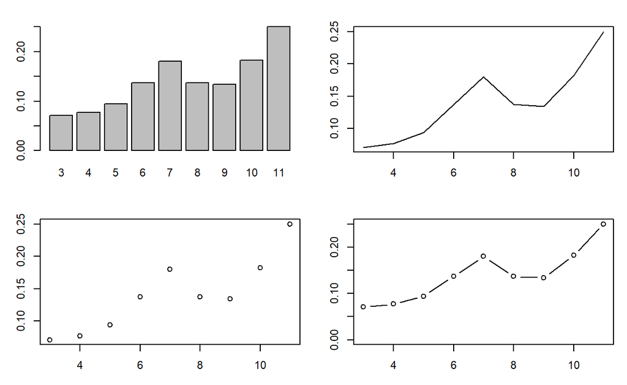

```r
# 繪製圖形序列以查看趨勢
par(mfcol=c(2,2), mar=c(3,3,2,1), cex=0.7)
v %>% barplot()               # 直條圖
plot(names(v), v)             # 散點圖
plot(names(v), v, type='l')   # 線形圖
plot(names(v), v, type='b', ylim=c(0,0.25)) # 帶標記的從零開始的線圖
```

以上哪以種方式比較容易看見正確的趨勢呢？ ANS:線形圖

##### 6.3 按分類排列的序列

`tapply(value, group, function)`可以一次接受多個分組變數，如

```r
v = tapply(D$align=="Bad", list(D$sex, D$decade), mean) %>% round(3); v
```

```
           3     4     5     6     7     8     9    10    11
Female 0.125 0.156 0.312 0.198 0.255 0.266 0.352 0.288 0.250
Male   0.050 0.274 0.289 0.559 0.480 0.457 0.513 0.414 0.439
```

🌻 `lines()`在現有繪圖中添加一條線。例如，我們可以比較不同性別的壞角色比例的趨勢，如下所示。

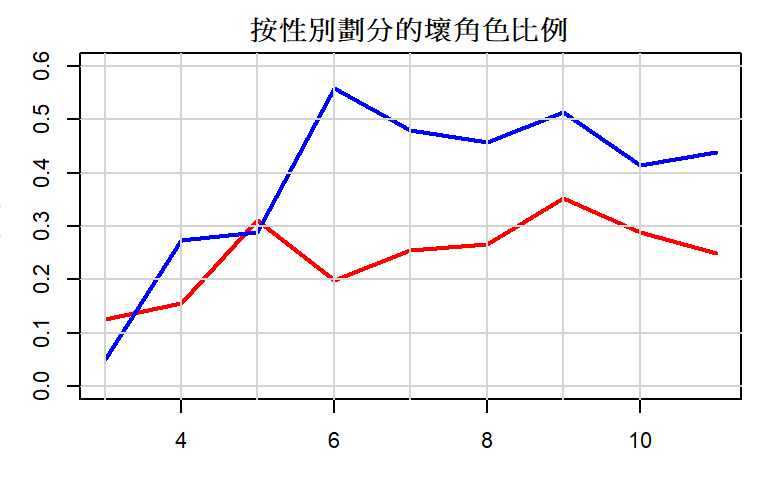

```r
par(mfrow=c(1,1), mar=c(3,3,2,1), cex=0.7)
plot(colnames(v),  v[1,], type="l", ylim=c(0,0.6), col="red", lwd=2,
     main = "按性別劃分的壞角色比例")                     # 添加標題
lines(colnames(v), v[2,], col="blue", lwd=2)              # 添加第二條線
abline(h=seq(0,0.6,0.1), v=seq(3,10,1), col='lightgray')  # 添加格線
```

確定前三種頭髮顏色…

```r
h3 = table(D$hair) %>% sort %>% tail(3) %>% names; h3
```

```
[1] "Blond" "Brown" "Black"
```

看看前三種頭髮顏色的比例如何隨時間變化。

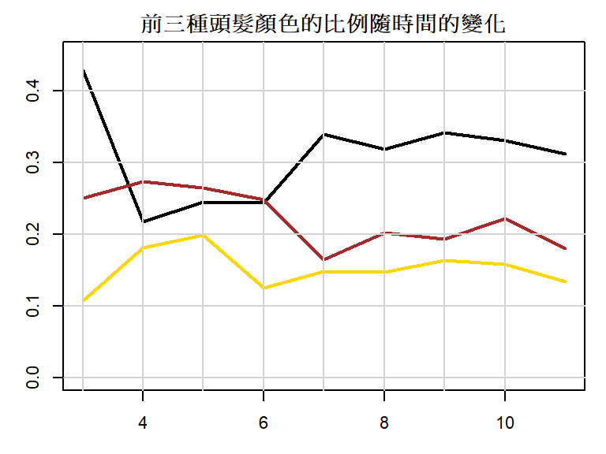

```r
par(mfrow=c(1,1), mar=c(3,3,2,1), cex=0.7)

v = tapply(D$hair=="Black", D$decade, mean)
plot(names(v),v,type='l',lwd=2,col="black",ylim=c(0,0.45),
     main="前三種頭髮顏色的比例隨時間的變化")

v = tapply(D$hair=="Brown", D$decade, mean)
lines(names(v),v,type='l',lwd=2,col="brown")

v = tapply(D$hair=="Blond", D$decade, mean)
lines(names(v),v,type='l',lwd=2,col="gold")

abline(h=seq(0,0.5,0.1), v=seq(3,10,1), col='lightgray')
```

🗿 QUIZ 6.3  
現在輪到你了。請製作圖表以…  
■ 檢查前三種眼睛顏色的比例趨勢  
■ 依據`漫畫公司`跟`性別`去比較`存活機率`的趨勢

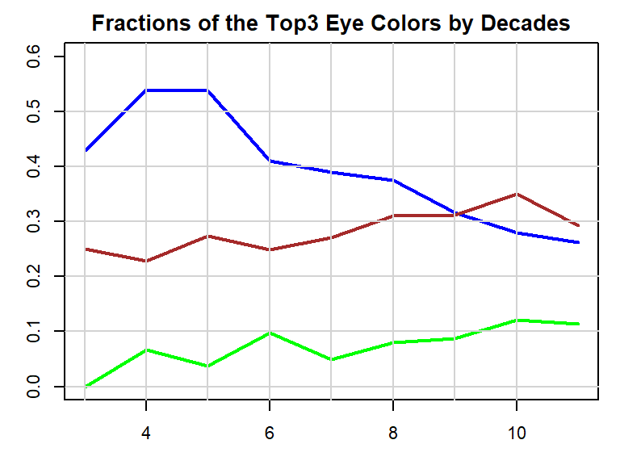

```r
par(mfrow=c(1,1), mar=c(3,3,2,1), cex=0.7)

v = tapply(D$eye=="Blue", D$decade, mean)
plot(names(v),v,type='l',lwd=2,col="blue",ylim=c(0,0.6),
     main="Fractions of the Top3 Eye Colors by Decades")

v = tapply(D$eye=="Brown", D$decade, mean)
lines(names(v),v,type='l',lwd=2,col="brown")

v = tapply(D$eye=="Green", D$decade, mean)
lines(names(v),v,type='l',lwd=2,col="green")

abline(h=seq(0,0.5,0.1), v=seq(3,10,1), col='lightgray')
```

```r
#藍有下降的趨勢，棕和綠整體算緩慢成長，不過還是藍棕比例佔大宗
```

[output not shown]

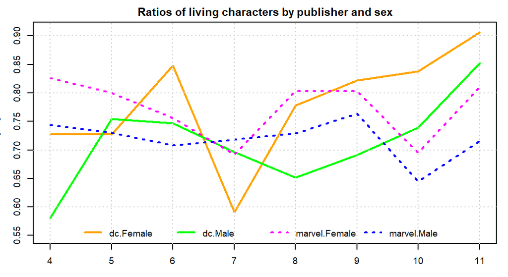

```r
par(mfrow=c(1,1), mar=c(3,3,2,1), cex=0.6)

cols = c("orange","green","magenta","blue")
ltys=c(1,1,3,3)

matplot(mx[-1,],type='l',lwd=2,col=cols, xaxt="n", ylim=c(0.55,0.91), lty=ltys,
        main = "Ratios of living characters by publisher and sex")

axis(1,at=1:8, labels=4:11)

abline(h=seq(0.6,0.9,0.1), v=1:8, col='lightgray', lty=3)

legend('bottom',colnames(mx),col=cols,lwd=2,horiz=T,bty='n',lty=ltys)
```

```r
#legend:圖例
#matplot:用矩陣的列畫圖
#xaxt='n':使X軸消失(不然下標會重疊)

#dc.female、dc.male整體而言存活率上升
#mar.female、mar.male整體而言算先下降再回升持平
#整體存活趨勢在後期都有明顯上升
```